## Reconstrucción filogenética y análisis comparativo de genes asociados a resistencia a antibióticos en bacterias patógenas

# Emilio Andrade (emilio.andrade375@gmail.com)

# Junio 25, 2025

# La resistencia a antibióticos es una caracteristica de ciertas bacterias que desarrollan la capacidad de sobrevivir y multiplicarse a pesar de estar expuestas a uno o más antibióticos que normalmente las matarían o inhibirían su crecimiento.

# ¿Porqué ocurre este fenómeno?

- Mutaciones genéticas que favorecen la resistencia a algún antibiótico, es un cambio aleatorio.
- Transferencia de genes: Las bacterias pueden compartir genes de resistencia entre sí a traves de mecanismos de conjugación.
- Uso inadecuado de antibioticos: Tomar antibioticos cuando no es necesario, no completar el tratamiento y el uso excesivo de antibióticos en la agricultura favorece a la resistencia.

# ¿Qué consecuencias tiene la resistencia de antibióticos?

- Las infecciones causadas por bacterias resistentes se vuelven más difíciles de tratar.
- Aumenta el riesgo de hospitalización, complicaciones y muerte.
- Se necesitan antibióticos más fuertes, costosos y con más efectos secundarios.

# Bacterias resistentes:

- Staphylococcus aureus resistente a meticilina (MRSA)

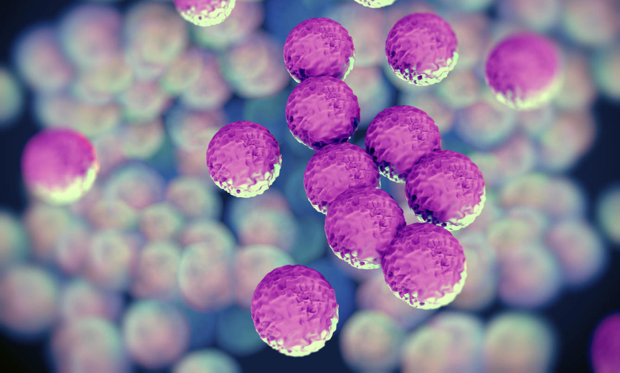

Staphylococcus aureus

- Escherichia coli resistente a múltiples fármacos

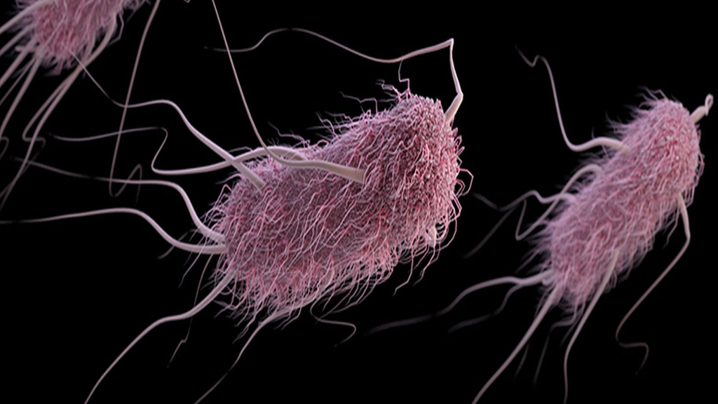

Escherichia coli

- Mycobacterium tuberculosis resistente a fármacos (MDR-TB)

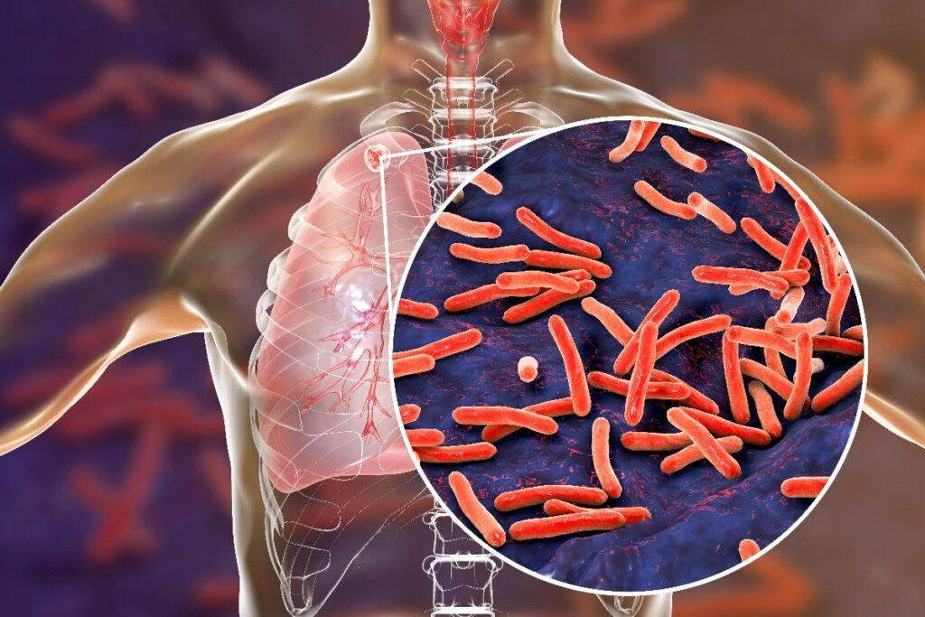

Mycobacterium tuberculosis

## Para empezar:

# En este proyecto llevamos a cabo la reconstrucción filogenética y el análisis comparativo de genes asociados a la resistencia a antibióticos en bacterias patógenas. Utilizando herramientas bioinformáticas, identificamos relaciones evolutivas entre genes resistentes y evaluamos su distribución entre distintos géneros bacterianos. Este enfoque permite entender cómo se diseminan los mecanismos de resistencia, lo que puede aportar al desarrollo de estrategias más efectivas para el control de infecciones bacterianas.

# Requisitos, programas a usar:

- Atom editor
- Musscle
- Iqtree
- Figtree
- Mesquite Java
- Git bash